# DSCI353-353m-453 & E1453-E2453: Class 10b Fundamentals of ML with NN

Profs: R. H. French, L. S. Bruckman, P. Leu, K. Davis, S. Cirlos

TAs: W. Oltjen, K. Hernandez, M. Li, M. Li, D. Colvin

21 February, 2023

```r
knitr::opts_chunk$set(
  cache = FALSE, # if TRUE knitr will cache results to reuse in future knits
  fig.width = 6, # the width for plots created by code chunk
  fig.height = 4, # the height for plots created by code chunk
  fig.align = 'center', # how to align graphics. 'left', 'right', 'center'
  dpi = 300,
  dev = 'png', # Makes each fig a png, and avoids plotting every data point
  # eval = FALSE, # if FALSE, then the R code chunks are not evaluated
  # results = 'asis', # knitr passes through results without reformatting
  echo = TRUE, # if FALSE knitr won't display code in chunk above it's results
  message = TRUE, # if FALSE knitr won't display messages generated by code
  strip.white = TRUE, # if FALSE knitr won't remove white spaces at beg or end of code chunk
  warning = TRUE, # if FALSE knitr won't display warning messages in the doc
  error = TRUE) # report errors
  # options(tinytex.verbose = TRUE)
```

#### Class Readings, Assignments, Textbooks Syllabus Topics

##### Textbooks

- Text Books for DSCI353/353M/453
  - [R4DS: Wickham: R for Data Science](https://r4ds.had.co.nz/)
  - [ISLR: Intro to Statistical Learning with R, 2nd Ed.](https://www.statlearning.com/)
  - DLwR: Deep Learning with R, Chollet, Allaire,
  - [DLGB: Deep Learning, Goodfellow, Bengio, Courville](https://www.deeplearningbook.org/)
- Magazine Articles about Deep Learning
  - DL1 to DL12 are “Deep Learning” articles in 3-readings/2-articles/

##### Syllabus

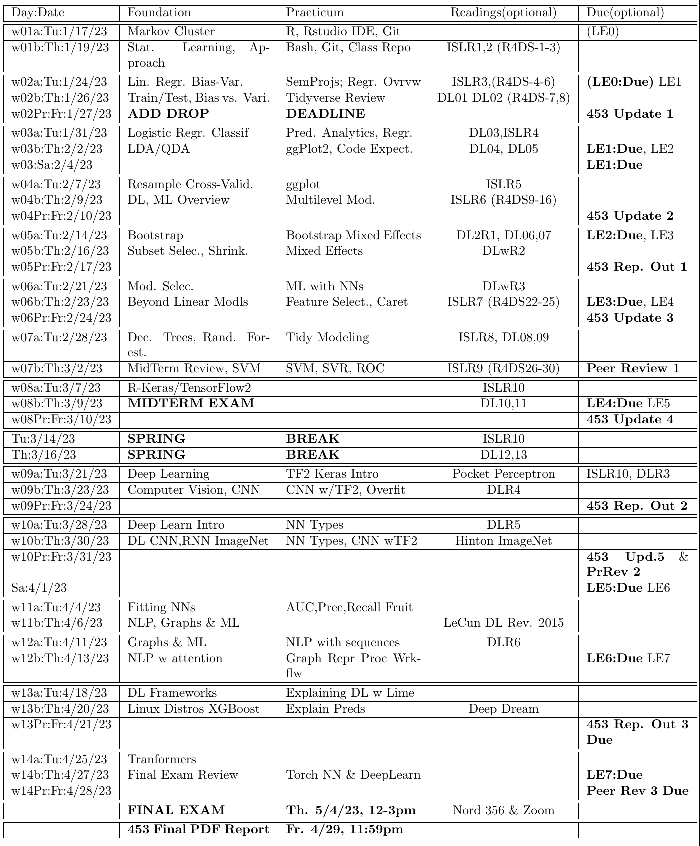

DSCI351-351M-451 Syllabus

#### Introduction to Machine Learning and Deep Learning with Neural Networks

- This is a companion notebook for the book
  - [Deep Learning with R, Second Edition](https://www.manning.com/books/deep-learning-with-R-second-edition).

For readability,

- it only contains runnable code blocks and section titles,
- and omits everything else in the book: text paragraphs, figures, and pseudocode.

**If you want to be able to follow what’s going on,**

- I recommend reading the notebook side by side with your copy of the book

This notebook was generated for TensorFlow 2.11.

This is using the [MNIST dataset](https://en.wikipedia.org/wiki/MNIST_database)

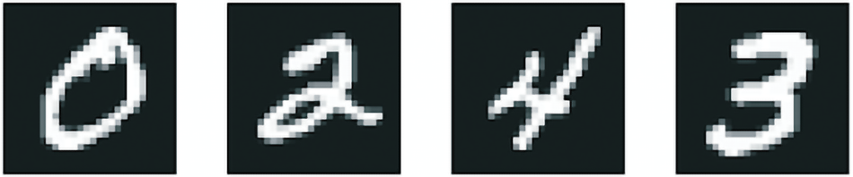

MNIST digist

MNIST images through a Neural Network Model layers

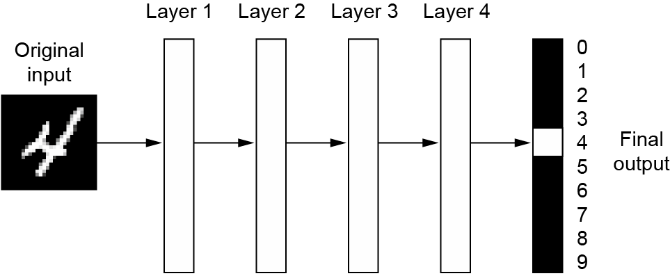

MNIST images through a Neural Network Model layers

MNIST and how the layers learn representations

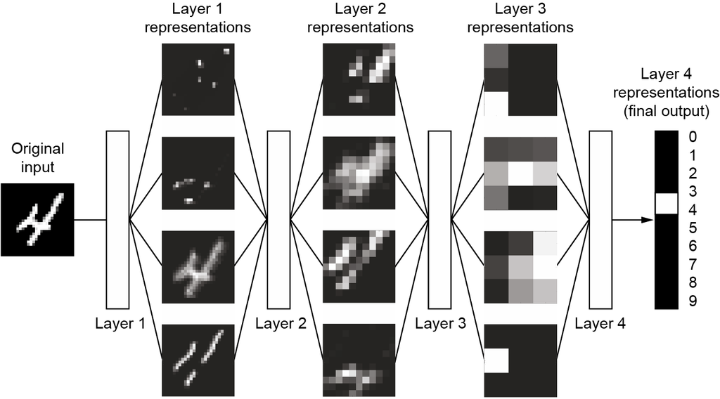

MNIST and how the layers learn representations.

#### Fundamentals of machine learning

##### Generalization: The goal of machine learning

- Underfitting and overfitting
- Noisy training data
- Ambiguous features
- Rare features and spurious correlations

##### **Adding white-noise channels or all-zeros channels to MNIST**

```r
library(keras)

mnist <- dataset_mnist()
```

[output not shown]

```r
train_labels <- mnist$train$y
train_images <- mnist$train$x %>%
  array_reshape(c(60000, 28 * 28))
train_images <- train_images / 255

noise_channels <- array(runif(nrow(train_images) * 784),
                        dim = c(nrow(train_images), 784))
train_images_with_noise_channels <-
  cbind(train_images, noise_channels)

zeros_channels <- array(0, dim = c(nrow(train_images), 784))
train_images_with_zeros_channels <-
  cbind(train_images, zeros_channels)
```

##### **Training the same model on MNIST data with noise channels or all-zero channels**

```r
library(keras)

get_model <- function() {
  model <- keras_model_sequential() %>%
    layer_dense(512, activation = "relu") %>%
    layer_dense(10, activation = "softmax")

  model %>% compile(optimizer = "rmsprop",
                    loss = "sparse_categorical_crossentropy",
                    metrics = "accuracy")

  model
}
```

```r
model <- get_model()
history_noise <- model %>% fit(
  train_images_with_noise_channels,
  train_labels,
  epochs = 10,
  batch_size = 128,
  validation_split = 0.2
)
```

```r
model <- get_model()
history_zeros <- model %>% fit(
  train_images_with_zeros_channels,
  train_labels,
  epochs = 10,
  batch_size = 128,
  validation_split = 0.2
)
```

##### **Plotting a validation accuracy comparison**

TODO: plot() should always draw to the graphics device,

- currently when method==ggplot it only returns a plot object
  - which should be the work of autoplot()
- data.frame(
  - “Validation accuracy with noise_channels” = history_noise$metrics$val_accuracy,
  - “Validation accuracy with zeros channels” = history_zeros$metrics$val_accuracy
  - %>% plot(type = ‘l’)

```r
library(patchwork)

plot(
  NULL,
  NULL,
  main = "Effect of Noise Channels on Validation Accuracy",
  xlab = "Epochs",
  xlim = c(1, history_noise$params$epochs),
  ylab = "Validation Accuracy",
  ylim = c(0.9, 1)
)
lines(history_zeros$metrics$val_accuracy,
      lty = 1,
      type = 'o')
```

[figure not shown]

```r
lines(history_noise$metrics$val_accuracy,
      lty = 2,
      type = 'o')
legend(
  "bottomright",
  legend = c(
    "Validation accuracy with zeros channels",
    "Validation accuracy with noise channels"
  ),
  lty = 1:2
)
```

#### The nature of generalization in deep learning

##### **Fitting a MNIST model with randomly shuffled labels**

```r
c(c(train_images, train_labels), .) %<-% dataset_mnist()
train_images <- train_images %>%
  array_reshape(c(60000, 28 * 28)) %>%
  `/`(255) #Q: do we teach this?

random_train_labels <- sample(train_labels)

model <- keras_model_sequential() %>%
  layer_dense(512, activation = "relu") %>%
  layer_dense(10, activation = "softmax")

summary(model)
```

```
Model: <no summary available, model was not built>
```

```r
model %>% compile(optimizer = "rmsprop",
                  loss = "sparse_categorical_crossentropy",
                  metrics = "accuracy")
```

```r
history <- model %>% fit(
  train_images,
  random_train_labels,
  epochs = 20, # best use 100 epochs
  batch_size = 128,
  validation_split = 0.2
)
summary(model)
```

```
Model: "sequential_2"
___________________________________________________________________________________
 Layer (type)                        Output Shape                     Param #
===================================================================================
 dense_5 (Dense)                     (None, 512)                      401920
 dense_4 (Dense)                     (None, 10)                       5130
===================================================================================
Total params: 407,050
Trainable params: 407,050
Non-trainable params: 0
___________________________________________________________________________________
```

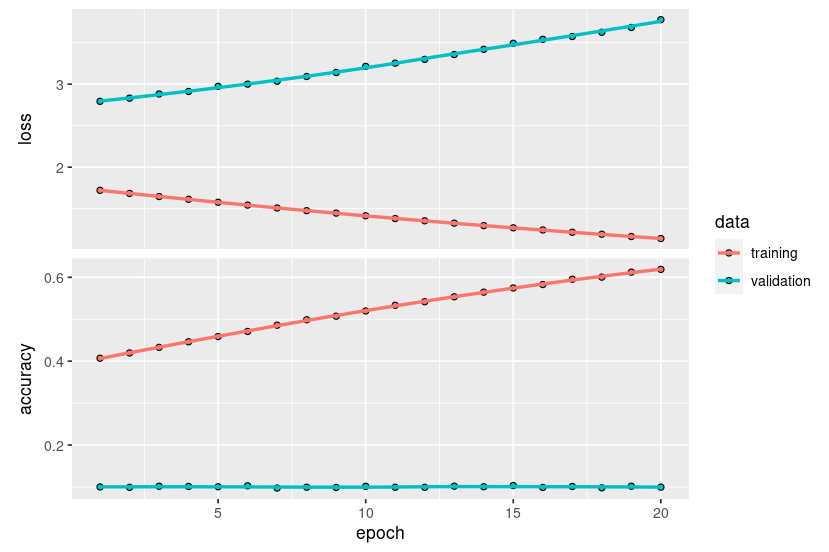

```r
plot(history)
```

#### The manifold hypothesis

- Interpolation as a source of generalization
- Why deep learning works
- Training data is paramount
- Evaluating machine-learning models
- Training, validation, and test sets
- Simple hold-out validation
- K-fold validation
- Iterated K-fold validation with shuffling
- Beating a common-sense baseline
- Things to keep in mind about model evaluation
- Improving model fit
- Tuning key gradient descent parameters

#### **Training a MNIST model with an incorrectly high learning rate**

```r
c(c(train_images, train_labels), .) %<-% dataset_mnist()
train_images <- train_images %>%
  array_reshape(c(60000, 28 * 28)) %>% `/`(255)

model <- keras_model_sequential(list(
  layer_dense(units = 512, activation = "relu"),
  layer_dense(units = 10, activation = "softmax")
))
model %>% compile(optimizer = optimizer_rmsprop(1.),
                  loss = "sparse_categorical_crossentropy",
                  metrics = "accuracy")
```

```r
model %>% fit(
  train_images,
  train_labels,
  epochs = 10,
  batch_size = 128,
  validation_split = 0.2
)
summary(model)
```

```
Model: "sequential_3"
_________________________________________________________________________________________________
 Layer (type)                              Output Shape                           Param #
=================================================================================================
 dense_6 (Dense)                           (None, 512)                            401920
 dense_7 (Dense)                           (None, 10)                             5130
=================================================================================================
Total params: 407,050
Trainable params: 407,050
Non-trainable params: 0
_________________________________________________________________________________________________
```

##### **The same model with a more appropriate learning rate**

```r
model <- keras_model_sequential(list(
  layer_dense(units = 512, activation = "relu"),
  layer_dense(units = 10, activation = "softmax")
))
model %>% compile(optimizer = optimizer_rmsprop(1e-2),
                  loss = "sparse_categorical_crossentropy",
                  metrics = "accuracy")
model %>% fit(
  train_images,
  train_labels,
  epochs = 10,
  batch_size = 128,
  validation_split = 0.2
)
summary(model)
```

```
Model: "sequential_4"
_________________________________________________________________________________________________
 Layer (type)                              Output Shape                           Param #
=================================================================================================
 dense_8 (Dense)                           (None, 512)                            401920
 dense_9 (Dense)                           (None, 10)                             5130
=================================================================================================
Total params: 407,050
Trainable params: 407,050
Non-trainable params: 0
_________________________________________________________________________________________________
```

#### Leveraging better architecture priors

##### Increasing model capacity

**A simple logistic regression on MNIST**

```r
model <- keras_model_sequential() %>%
  layer_dense(10, activation = "softmax")
model %>% compile(optimizer = "rmsprop",
                  loss = "sparse_categorical_crossentropy",
                  metrics = "accuracy")
history_small_model <- model %>% fit(
  train_images,
  train_labels,
  epochs = 20,
  batch_size = 128,
  validation_split = 0.2
)
summary(model)
```

```
Model: "sequential_5"
_________________________________________________________________________________________________
 Layer (type)                              Output Shape                           Param #
=================================================================================================
 dense_10 (Dense)                          (None, 10)                             7850
=================================================================================================
Total params: 7,850
Trainable params: 7,850
Non-trainable params: 0
_________________________________________________________________________________________________
```

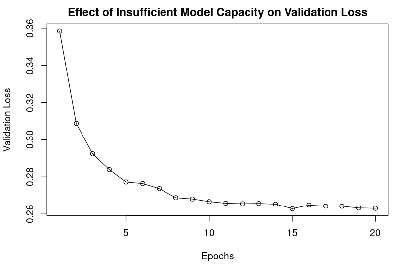

```r
dplyr::as_tibble(history_small_model) %>%
  dplyr::filter(metric == "loss", data == "validation") %>%
  plot(
    value ~ epoch,
    data = .,
    type = "o",
    main = "Effect of Insufficient Model Capacity on Validation Loss",
    xlab = "Epochs",
    ylab = "Validation Loss"
  )
```

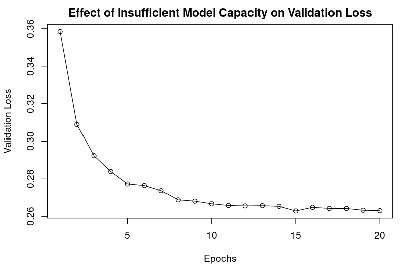

```r
# w/o going through data.frame
plot(
  history_small_model$metrics$val_loss,
  type = 'o',
  main = "Effect of Insufficient Model Capacity on Validation Loss",
  xlab = "Epochs",
  ylab = "Validation Loss"
)
```

```r
model <- keras_model_sequential() %>%
  layer_dense(96, activation = "relu") %>%
  layer_dense(96, activation = "relu") %>%
  layer_dense(10, activation = "softmax")

model %>% compile(optimizer = "rmsprop",
                  loss = "sparse_categorical_crossentropy",
                  metrics = "accuracy")
history_large_model = model %>% fit(
  train_images,
  train_labels,
  epochs = 20,
  batch_size = 128,
  validation_split = 0.2
)
summary(model)
```

```
Model: "sequential_6"
_________________________________________________________________________________________________
 Layer (type)                              Output Shape                           Param #
=================================================================================================
 dense_13 (Dense)                          (None, 96)                             75360
 dense_12 (Dense)                          (None, 96)                             9312
 dense_11 (Dense)                          (None, 10)                             970
=================================================================================================
Total params: 85,642
Trainable params: 85,642
Non-trainable params: 0
_________________________________________________________________________________________________
```

#### Improving generalization

- Dataset curation
- Feature engineering
- Using early stopping
- Regularizing your model
- Reducing the network’s size

**Original model**

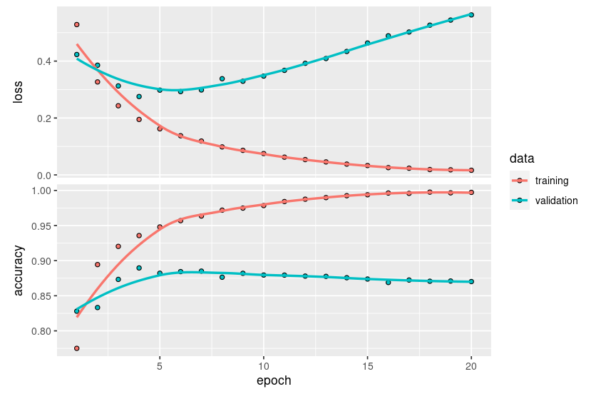

```r
c(c(train_data, train_labels), .) %<-% dataset_imdb(num_words = 10000)

vectorize_sequences <- function(sequences, dimension = 10000) {
  results <- matrix(0, nrow = length(sequences), ncol = dimension)
  # results[cbind(seq_along(sequences), sequences)] <- 1
  for (i in seq_along(sequences))
    results[i, sequences[[i]]] <- 1.
  results
}
train_data <- vectorize_sequences(train_data)

model <- keras_model_sequential() %>%
  layer_dense(16, activation = "relu") %>%
  layer_dense(16, activation = "relu") %>%
  layer_dense(1, activation = "sigmoid")

model %>% compile(optimizer = "rmsprop",
                  loss = "binary_crossentropy",
                  metrics = "accuracy")

history_original <- model %>% fit(
  train_data,
  train_labels,
  epochs = 20,
  batch_size = 512,
  validation_split = 0.4
)
plot(history_original)
```

```r
summary(model)
```

```
Model: "sequential_7"
_________________________________________________________________________________________________
 Layer (type)                              Output Shape                           Param #
=================================================================================================
 dense_16 (Dense)                          (None, 16)                             160016
 dense_15 (Dense)                          (None, 16)                             272
 dense_14 (Dense)                          (None, 1)                              17
=================================================================================================
Total params: 160,305
Trainable params: 160,305
Non-trainable params: 0
_________________________________________________________________________________________________
```

**Version of the model with lower capacity**

```r
model = keras_model_sequential() %>%
  layer_dense(4, activation = "relu") %>%
  layer_dense(4, activation = "relu") %>%
  layer_dense(1, activation = "sigmoid")

model %>% compile(optimizer = "rmsprop",
                  loss = "binary_crossentropy",
                  metrics = "accuracy")

history_smaller_model <- model %>% fit(
  train_data,
  train_labels,
  epochs = 20,
  batch_size = 512,
  validation_split = 0.4
)
summary(model)
```

```
Model: "sequential_9"
_________________________________________________________________________________________________
 Layer (type)                              Output Shape                           Param #
=================================================================================================
 dense_22 (Dense)                          (None, 4)                              40004
 dense_21 (Dense)                          (None, 4)                              20
 dense_20 (Dense)                          (None, 1)                              5
=================================================================================================
Total params: 40,029
Trainable params: 40,029
Non-trainable params: 0
_________________________________________________________________________________________________
```

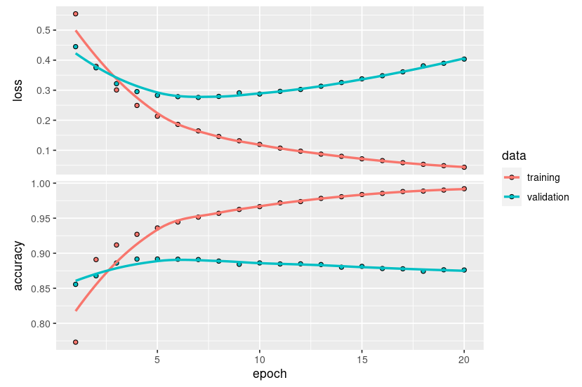

```r
plot(history_smaller_model)
```

**Version of the model with higher capacity**

```r
model = keras_model_sequential() %>%
  layer_dense(512, activation = "relu") %>%
  layer_dense(512, activation = "relu") %>%
  layer_dense(1, activation = "sigmoid")

model %>% compile(optimizer = "rmsprop",
                  loss = "binary_crossentropy",
                  metrics = "accuracy")

history_larger_model <- model %>% fit(
  train_data,
  train_labels,
  epochs = 20,
  batch_size = 512,
  validation_split = 0.4
)
summary(model)
```

```
Model: "sequential_10"
_________________________________________________________________________________________________
 Layer (type)                              Output Shape                           Param #
=================================================================================================
 dense_25 (Dense)                          (None, 512)                            5120512
 dense_24 (Dense)                          (None, 512)                            262656
 dense_23 (Dense)                          (None, 1)                              513
=================================================================================================
Total params: 5,383,681
Trainable params: 5,383,681
Non-trainable params: 0
_________________________________________________________________________________________________
```

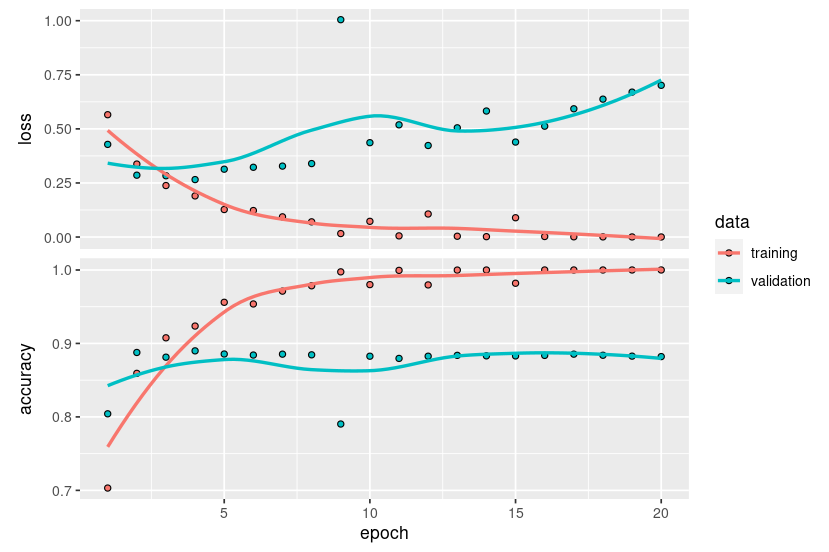

```r
plot(history_larger_model)
```

##### Adding weight regularization

**Adding L2 weight regularization to the model**

```r
model <- keras_model_sequential() %>%
  layer_dense(16,
              kernel_regularizer = regularizer_l2(0.002),
              activation = "relu") %>%
  layer_dense(16,
              kernel_regularizer = regularizer_l2(0.002),
              activation = "relu") %>%
  layer_dense(1, activation = "sigmoid")

model %>% compile(optimizer = "rmsprop",
                  loss = "binary_crossentropy",
                  metrics = "accuracy")
history_l2_reg <- model %>% fit(
  train_data,
  train_labels,
  epochs = 20,
  batch_size = 512,
  validation_split = 0.4
)
summary(model)
```

```
Model: "sequential_11"
_________________________________________________________________________________________________
 Layer (type)                              Output Shape                           Param #
=================================================================================================
 dense_28 (Dense)                          (None, 16)                             160016
 dense_27 (Dense)                          (None, 16)                             272
 dense_26 (Dense)                          (None, 1)                              17
=================================================================================================
Total params: 160,305
Trainable params: 160,305
Non-trainable params: 0
_________________________________________________________________________________________________
```

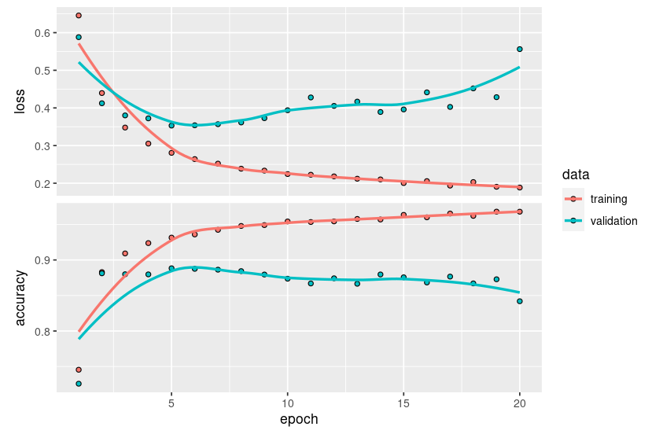

```r
plot(history_l2_reg)
```

**Different weight regularizers available in Keras**

```r
regularizer_l1(0.001)
```

```
<keras.regularizers.L1 object at 0x7f7cdf303940>
```

```r
regularizer_l1_l2(l1 = 0.001, l2 = 0.001)
```

```
<keras.regularizers.L1L2 object at 0x7f7cdf371a60>
```

##### Adding dropout

**Adding dropout to the IMDB model**

```r
model <- keras_model_sequential() %>%
  layer_dense(16, activation = "relu") %>%
  layer_dropout(0.5) %>%
  layer_dense(16, activation = "relu") %>%
  layer_dropout(0.5) %>%
  layer_dense(1, activation = "sigmoid")

model %>% compile(optimizer = "rmsprop",
                  loss = "binary_crossentropy",
                  metrics = "accuracy")
history_dropout <- model %>% fit(
  train_data,
  train_labels,
  epochs = 20,
  batch_size = 512,
  validation_split = 0.4
)
summary(model)
```

```
Model: "sequential_12"
_________________________________________________________________________________________________
 Layer (type)                              Output Shape                           Param #
=================================================================================================
 dense_31 (Dense)                          (None, 16)                             160016
 dropout_1 (Dropout)                       (None, 16)                             0
 dense_30 (Dense)                          (None, 16)                             272
 dropout (Dropout)                         (None, 16)                             0
 dense_29 (Dense)                          (None, 1)                              17
=================================================================================================
Total params: 160,305
Trainable params: 160,305
Non-trainable params: 0
_________________________________________________________________________________________________
```

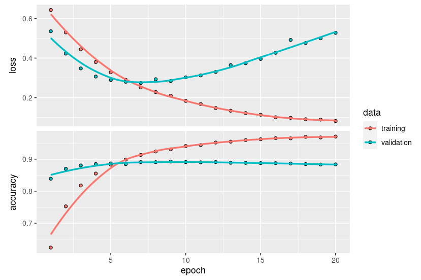

```r
plot(history_dropout)
```

#### Links

- Chollet, Allaire, Deep Learning with R, 2nd Edition